# Census Data Wrangling and Mapping in R - Tutorial

Patty Frontiera

11/17/2021

# R Census Data - Tutorial Time!

## Part 1

We will work through several exercises using `tidycensus` to fetch, wrangle, and map census data.

## Setup

Be sure to **clone or downloaded and unzip** the workshop files from: https://github.com/dlab-berkeley/Census-Data-in-R

Then:

1. Open the folder with the workshop files
2. Double-click on the R Project file `Census-Data-in-R.Rproj`
3. This should open RStudio - with the `Files` panel displaying the workshop folder contents.
4. Double-click on the file `Rcensus_data_maps-tutorial.Rmd` to follow along!

*You can also click on the file `Rcensus_data_maps-tutorial.html` in the Files tab to open the workshop tutorial in a web brower.*

## Install packages

Install any packages we will use that are not already installed on your system.

- If you installed any of these awhile ago it’s a good idea to install updates (though not during the workshop as things can break!)

Basic syntax to install an R package:

> `install.packages("package_name")`

Here is some code to install a set of R packages.

```r
# Create a list of the packages we will use
list_of_packages <- c("tidyverse","sf","mapview","tigris", "tidycensus")

# Identify any new packages that will need to be installed
new_packages <- list_of_packages[!(list_of_packages %in% installed.packages()[,"Package"])]

# Install any packages that are not installed (new_packages)
if(length(new_packages) > 0) {
  print(paste("Installing these packages:", new_packages))
  install.packages(new_packages)
} else {
  print("All packages already installed!")
}
```

```
## [1] "All packages already installed!"
```

## Loading packages

Use the `library` function to load the R packages we will use today

```r
library(tidycensus)
library(tidyverse)
library(sf)
library(mapview)
```

## Census API Key

You need a `Census API key` to programmatically fetch census data.

- Get it here (pretty quickly): https://api.census.gov/data/key_signup.html
- The key will be sent to your email and you will need to click to activate it.
- Keep the email with the key open for use in this workshop.

*For more info on all available Census APIs see: https://www.census.gov/data/developers/data-sets.html*

## Census Data with the `tidycensus` R package

The [tidycensus](https://walker-data.com/tidycensus/index.html) package allows R users to quickly fetch data from a select subset of Census databases.

- Many of the code samples in this tutorial borrow heavily from [Kyle Walker’s](https://walker-data.com) tidycensus package documentation.

The key tidycensus functions we will use today are:

- `census_api_key`: makes your Census API key available to tidycensus
- `load_variables`: retrieves a dataframe of available census data variables
- `get_decennial`: fetch census data for the most recent decennial censuses - 2000, 2010 (and soon 2020)
- `get_acs`: fetch 2005 - 2020 data from the 1 and 5 year ACS (American Community Survey) data bases

## Add Your Census API Key

Let’s get started!

1. Copy and paste your Census API key from your email
2. Use the tidycensus function **census_api_key** to register your API key with tidycensus. **Don’t forget to put quotes around the key!**.

```r
# Install your census api key - long alphanumeric string
census_api_key("THE_BIG_LONG_ALPHANUMERIC_API_KEY_YOU_GOT_FROM_CENSUS")
```

## Another way to add your Census API Key

I keep my key in a file so no one can see it

```r
# source (run) an r script that creates a variable with my key
source("../../keys/census_api_key.R")

#print(my_census_api_key)

# register the key
census_api_key(key = my_census_api_key)
```

```
## To install your API key for use in future sessions, run this function with `install = TRUE`.
```

# Fetching Decennial Census Data

## `get_decennial` function

We will start by fetching from the 2010 Census with tidycensus’s `get_decennial` function. Let’s first talk about the code.

```r
pop2010 <- get_decennial(geography = "state",   # census tabulation unit
                         variables = "P001001", # variable(s) of interest
                         year = 2010)           # census year
```

```
## Using Census Summary File 1
```

```r
head(pop2010)
```

```
## # A tibble: 6 x 4
##   GEOID NAME       variable    value
##   <chr> <chr>      <chr>       <dbl>
## 1 01    Alabama    P001001   4779736
## 2 02    Alaska     P001001    710231
## 3 04    Arizona    P001001   6392017
## 4 05    Arkansas   P001001   2915918
## 5 06    California P001001  37253956
## 6 22    Louisiana  P001001   4533372
```

## tidycensus data is `tidy`

By default, tidycensus returns data in a `tidy`, or `long` format that allows data for multiple variables to be contained within the `variable` and `value` columns. This is in contract to untidy, or `wide` data where each variable is in its own column.

```r
# wide format
pop2010w <- get_decennial(geography = "state",   # census tabulation unit
                         variables = "P001001", # variable(s) of interest
                         year = 2010,           # census year
                         output="wide")         # get output in wide format
```

```
## Using Census Summary File 1
```

```r
head(pop2010w)
```

```
## # A tibble: 6 x 3
##   GEOID NAME        P001001
##   <chr> <chr>         <dbl>
## 1 01    Alabama     4779736
## 2 02    Alaska       710231
## 3 04    Arizona     6392017
## 4 05    Arkansas    2915918
## 5 06    California 37253956
## 6 22    Louisiana   4533372
```

## The `GEOID` column

The `GEOID` column is included in tidycensus output.

This is a Census geographic identifier for the tabulation unit.

The `GEOID` is sometimes called the Census `FIPS` code and for most tabulation units these are the same.

- This makes it possible to link to Census geographic data and make maps. (We will do this in a bit.)

The `GEOID` is a text string and must be quoted.

- Beware of GEOID leading zeros, since some software will remove these and convert GEIOD values to numbers (rather than text strings).

#### Question:

*What is the GEOID for California*

## Census Tabulation Units

Decennial census data is gathered from individuals and publicly distributed in aggregated form to protect privacy.

The Census tabulation units are the Census geographies to which the census data have been aggregated.

Some of the most common geographic tabulation units and their tidycensus function abbreviations are shown below, along with **required** and available filters that limit what data are returned.

| Geography | Definition | Filter(s) | Used in tidycensus |
| --- | --- | --- | --- |
| “us” | United States |  | get_acs(), get_decennial() |
| “region” | Census region |  | get_acs(), get_decennial() |
| “state” | State or equivalent | state | get_acs(), get_decennial() |
| “county” | County or equivalent | state, county | get_acs(), get_decennial() |
| “place” | Census place | state | get_acs(), get_decennial() |
| “tract” | Census tract | **state**, county | get_acs(), get_decennial() |
| “block group” | Census block group | **state**, county | get_acs(), get_decennial() |
| “block” | Census block | **state**, **county** | get_decennial() only! |

## `get_decennial` Geographic Tabulation Units and Filters

Let’s work together to fill in the code to fetch state population in 2010 just for California. You can find the code in the file `Solutions.R`.

- See `?get_decennial` for help

```r
#Fill in the code to fetch State population in 2010 just for California

get_decennial(geography = "state",               # census tabulation unit
                          variables = "P001001", # variable(s) of interest
                          year = 2010,           # census year
                          ...........)           # Filter by state is CA
```

Alter the above code to fetch state pop in 2010 for CA, TX and FL

```r
# Your code below or see Solutions.R
## fetch state pop in 2010 for CA, TX and FL
```

## Change the tabulation unit

Let’s fetch 2010 population data for CA counties

- *What changes in the code?*

```r
get_decennial(geography = "county",              # census tabulation unit
                          variables = "P001001", # variable(s) of interest
                          year = 2010,           # census year
                          state='CA')            # Filter by state is CA
```

```
## Using Census Summary File 1
```

```
## # A tibble: 58 x 4
##    GEOID NAME                            variable   value
##    <chr> <chr>                           <chr>      <dbl>
##  1 06011 Colusa County, California       P001001    21419
##  2 06007 Butte County, California        P001001   220000
##  3 06001 Alameda County, California      P001001  1510271
##  4 06003 Alpine County, California       P001001     1175
##  5 06005 Amador County, California       P001001    38091
##  6 06009 Calaveras County, California    P001001    45578
##  7 06013 Contra Costa County, California P001001  1049025
##  8 06015 Del Norte County, California    P001001    28610
##  9 06031 Kings County, California        P001001   152982
## 10 06021 Glenn County, California        P001001    28122
## # … with 48 more rows
```

#### Questions

- How do we specify the state of CA above? How else can we?
- Can you fetch population data for all counties in the USA or do you need to have a `state=` filter?

## Adding a county filter

You can also filter tidycensus results by `county`

```r
get_decennial(geography = "county",              # census tabulation unit
                          variables = "P001001", # variable(s) of interest
                          year = 2010,           # census year
                          state='CA',            # Filter by state is CA
                          county='Alameda')      # Filter by county Alameda
```

```
## Using Census Summary File 1
```

```
## # A tibble: 1 x 4
##   GEOID NAME                       variable   value
##   <chr> <chr>                      <chr>      <dbl>
## 1 06001 Alameda County, California P001001  1510271
```

Alter the code above to fetch 2010 population for Alameda & San Francisco Counties

```r
# Your code below or see Solutions.R
## fetch 2010 population for Alameda & San Francisco Counties
```

## Visualize Results

We can visualize the data to get a quick overview of the distribution of data values.

It’s a first step in exploratory data analysis and a last step in data communication.

`ggplot2` is the most commonly used R package for data visualization.

- It is loaded when you load the `tidyverse` package.

Let’s use it to visualize the population data.

## Plot 2010 Population by state

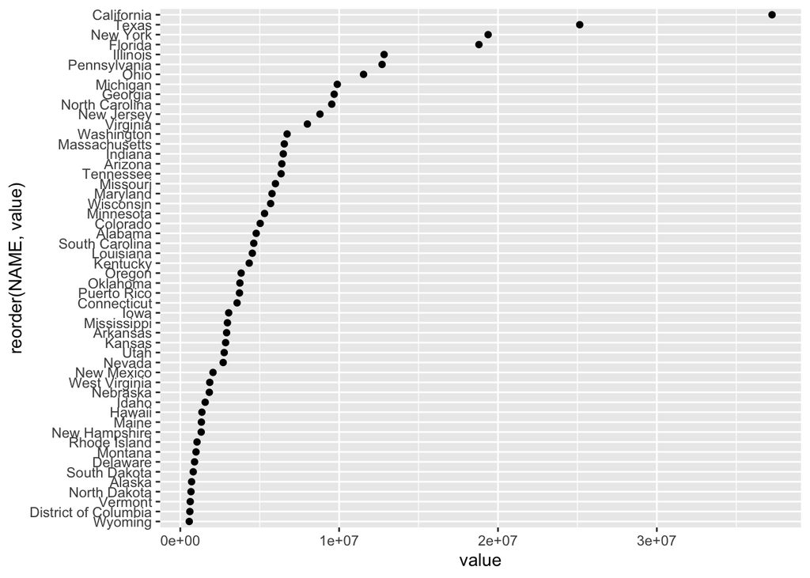

```r
pop_plot <- ggplot(data=pop2010,
                  aes(x=value, y=reorder(NAME,value)) ) +
                  geom_point()

# display the plot
pop_plot
```

# If you know ggplot you can get real fancy

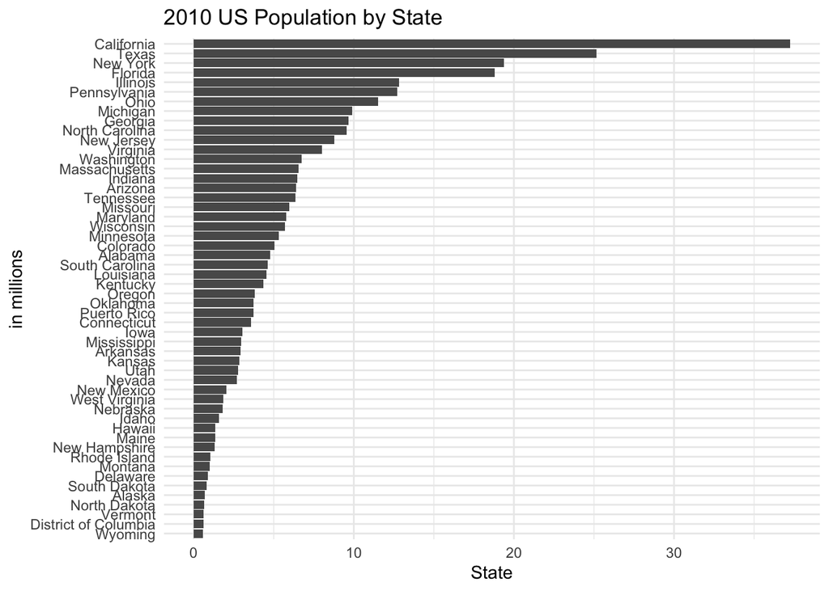

```r
pop_plot <- ggplot(data=pop2010,
                   aes(x=value/1000000, y=reorder(NAME,value)) ) +
                   geom_bar(stat="identity") +
                   theme_minimal() +
                   labs(title = "2010 US Population by State") +
                   xlab("State") +
                   ylab("in millions")

# display the plot
pop_plot
```

## Identifying Census Variables

In the code above we fetched data for total population in 2010 using the variable `"P001001"`.

That is not an obvious variable name, so how do we get those identifiers?

We can use the tidycensus **load_variables** function for this.

## load_variables

Use `load_variables` to fetch all variables used in the 2010 census into a dataframe.

```r
vars2010 <- load_variables(year=2010,        # Year or end year for ACS-5yr
                           dataset = 'sf1',  # 'sf1' for decennial census
                           cache = TRUE)     # Save fetched data locally

# How large is the output
dim(vars2010)
```

```
## [1] 8959    3
```

```r
# Take a look with head or View
head(vars2010)
```

```
## # A tibble: 6 x 3
##   name    label                                concept
##   <chr>   <chr>                                <chr>
## 1 H001001 Total                                HOUSING UNITS
## 2 H002001 Total                                URBAN AND RURAL
## 3 H002002 Total!!Urban                         URBAN AND RURAL
## 4 H002003 Total!!Urban!!Inside urbanized areas URBAN AND RURAL
## 5 H002004 Total!!Urban!!Inside urban clusters  URBAN AND RURAL
## 6 H002005 Total!!Rural                         URBAN AND RURAL
```

## 2010 Decennial Census Tables & Variables

https://www.census.gov/data/datasets/2010/dec/summary-file-1.html

## What Variable Has the 2010 Total Population value?

We can sort and filter the vars2010 dataframe to find it.

### Questions

What 2010 decennial census variable contains…

- `Median Age`
- `Average Family Size`
- `Number of occupied housing units`

*Answers are in Solutions.R*

## Challenge

Complete the code cell below (…) to fetch and plot `Avg Family Size` by CA County in `2010`. *See Solutions.R for the code.*

```r
# Fetch Avg family size by CA County
ca_fam_size <- get_decennial(...)

# plot it
ca_fam_size %>%
  ggplot(aes(x = value, y = reorder(NAME, value))) +
  geom_point()
```

## Challenge

Repeat the previous challenge with data from the `2000` decennial census.

Don’t assume variable names are the same across the 2000 and 2010 census

- Use `load_variables` to check!

*See Solutions.R for the code*

```r
# Add your code below
```

## Census Tract Data

Census tracts are the most commonly used census tabulation unit.

Let’s fetch population data for the census tabulation unit to *tract*

> Because of the large number of census tracts, you MUST specify a state when requesting these data with tidycensus.

## Census Tract Data

Fetch total population for California by census tract

```r
## Fetch population by **tract** for California.
ca_tract_pop2010 <- get_decennial(geography = "tract",   # census tab unit
                                   variables = "P001001", # var of interest
                                   year = 2010,           # census year
                                   state='CA')      # State filter
```

```
## Using Census Summary File 1
```

```r
# How many tracts in CA
dim(ca_tract_pop2010)
```

```
## [1] 8057    4
```

```r
# take a look
head(ca_tract_pop2010)
```

```
## # A tibble: 6 x 4
##   GEOID       NAME                                                variable value
##   <chr>       <chr>                                               <chr>    <dbl>
## 1 06037434004 Census Tract 4340.04, Los Angeles County, Californ… P001001   2796
## 2 06037460000 Census Tract 4600, Los Angeles County, California   P001001   4851
## 3 06037460200 Census Tract 4602, Los Angeles County, California   P001001   5315
## 4 06037460301 Census Tract 4603.01, Los Angeles County, Californ… P001001   4638
## 5 06037460302 Census Tract 4603.02, Los Angeles County, Californ… P001001   4442
## 6 06037460401 Census Tract 4604.01, Los Angeles County, Californ… P001001    878
```

## Fetching Census Tract Data

Census tract data can be quite large!

Fortunately, you can also limit the results to one or more counties.

```r
tract_pop2010 <- get_decennial(geography = "tract",   # census tabulation unit
                         variables = "P001001",       # variable of interest
                         year = 2010,                 # census year - only one!
                         state="CA",                  # limit to California
                         county=c("Alameda","Contra Costa"))  # & counties
```

```
## Using Census Summary File 1
```

```r
dim(tract_pop2010)
```

```
## [1] 569   4
```

## Fetching data for more than one census variable

What **three** things are new here?

```r
#urban and rural pop for 3 CA counties
ur_pop10 <- get_decennial(geography = "county",  # census tabulation unit
                           variables = c(urban="P002002",rural="P002005"),
                           year = 2010,
                           summary_var = "P002001",  # The denominator
                           state='CA',
                           county=c("Napa","Sonoma","Mendocino"))
```

```
## Using Census Summary File 1
```

## Fetching data for more than one census variable

1. You can specify more than one variable:

```
variables = c("P002002","P002005")
```

2. You can rename the values in the output ‘variable’ column.

```
variables = c(urban="P002002",rural="P002005")
```

3. You can identify a `summary_var` (a denominator - here, the total count of all people or households surveyed. Can be used for calculations like percent of total.)

```
summary_var = "P002001"
```

## Take a look at the results

```r
ur_pop10
```

```
## # A tibble: 6 x 5
##   GEOID NAME                         variable  value summary_value
##   <chr> <chr>                        <chr>     <dbl>         <dbl>
## 1 06045 Mendocino County, California urban     48110         87841
## 2 06055 Napa County, California      urban    118194        136484
## 3 06097 Sonoma County, California    urban    424102        483878
## 4 06045 Mendocino County, California rural     39731         87841
## 5 06055 Napa County, California      rural     18290        136484
## 6 06097 Sonoma County, California    rural     59776        483878
```

## Calculating Percents

The `summary_value` column comes in handy when you want to compute percent of total, for example:

```r
# Calculate the percent of population that is Urban or Rural
ur_pop10 <- ur_pop10 %>%
            mutate(pct = 100 * (value / summary_value))

# Take a look at the output.
ur_pop10
```

```
## # A tibble: 6 x 6
##   GEOID NAME                         variable  value summary_value   pct
##   <chr> <chr>                        <chr>     <dbl>         <dbl> <dbl>
## 1 06045 Mendocino County, California urban     48110         87841  54.8
## 2 06055 Napa County, California      urban    118194        136484  86.6
## 3 06097 Sonoma County, California    urban    424102        483878  87.6
## 4 06045 Mendocino County, California rural     39731         87841  45.2
## 5 06055 Napa County, California      rural     18290        136484  13.4
## 6 06097 Sonoma County, California    rural     59776        483878  12.4
```

## Plot it

Plots give us compact visual summaries of the data.

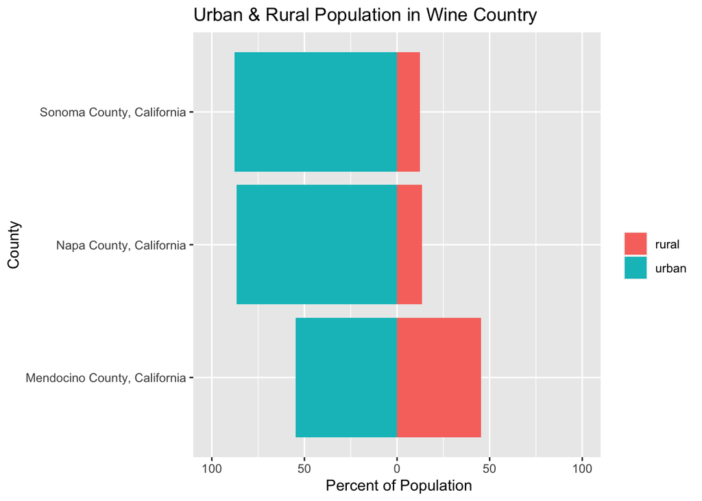

```r
myplot <- ggplot(data = ur_pop10,
          mapping = aes(x = NAME, fill = variable,
                     y = ifelse(test = variable == "urban",
                                yes = -pct, no = pct))) +
          geom_bar(stat = "identity") +
          scale_y_continuous(labels = abs, limits=c(-100,100)) +
          labs(title="Urban & Rural Population in Wine Country",
               x="County", y = " Percent of Population", fill="") +
          coord_flip()

# plot it
myplot
```

Don’t worry if you don’t get all the ggplot code now. It’s here for reference.

- You may want to check out our *R Data Visualization with ggplot* workshop!

## Data Wrangling

Your R skills can help you reformat the data and make it more usable.

Let’s fetch population data for 2010 and 2000 by state.

Then we will combine these into one data frame using the `tidyverses::bind_rows` function

```r
# Fetch 2000 population data by state
pop2000 <- get_decennial(geography = "state",
                         variables = c(pop2000="P001001"),
                         year = 2000)
```

```
## Using Census Summary File 1
```

```r
# Fetch 2010 population data by state
pop2010 <- get_decennial(geography = "state",
                         variables = c(pop2010="P001001"),
                         year = 2010)
```

```
## Using Census Summary File 1
```

```r
# Use tidyverse `bind_rows` function to combine the data for these years
state_pop <- bind_rows(pop2000, pop2010)

# Take a look with head or View
head(state_pop)
```

```
## # A tibble: 6 x 4
##   GEOID NAME       variable    value
##   <chr> <chr>      <chr>       <dbl>
## 1 01    Alabama    pop2000   4447100
## 2 02    Alaska     pop2000    626932
## 3 04    Arizona    pop2000   5130632
## 4 05    Arkansas   pop2000   2673400
## 5 06    California pop2000  33871648
## 6 08    Colorado   pop2000   4301261
```

# Part 2. Mapping

## Mapping Census Data with `tidycensus`

You can fetch census geographic data by adding the parameter **geometry=TRUE** to `tidycensus` functions

- Under the hood, tidycensus calls the `tigris` package to fetch data from the Census Geographic Data APIs.
- Only a subset of data available via `tigris` can be accessed via `tidycensus`.

You can then use your favorite R mapping functions or libraries like `plot`, `ggplot`, and `tmap` to make maps.

## Geometry Options

Before fetching census geographic data, we need to set the option `tigris_use_cache` to TRUE

Caching saves data locally. This greatly speeds things up if you fetch the same census geographic data repeatedly.

```r
# Tigris options - used by tidycensus
# Cache retrieved geographic data locally
options(tigris_use_cache = TRUE)
```

## Fetch Geographic Boundary Data with `tidycensus`

We fetch the geospatial data by setting **geometry=TRUE**.

```r
pop2010geo <- get_decennial(geography = "state",
                          variables = c(pop10="P001001"),
                          year = 2010,
                          output="wide",
                          geometry=TRUE) # Fetch geometry data for mapping
```

```
## Using Census Summary File 1
```

## Take a look

Let’s take a minute to discuss the format of an `sf` spatial object.

```r
head(pop2010geo, 3)
```

```
## Simple feature collection with 3 features and 3 fields
## Geometry type: MULTIPOLYGON
## Dimension:     XY
## Bounding box:  xmin: -90.41814 ymin: 41.23796 xmax: -66.9499 ymax: 48.19097
## Geodetic CRS:  NAD83
## # A tibble: 3 x 4
##   GEOID NAME        pop10                                               geometry
##   <chr> <chr>       <dbl>                                     <MULTIPOLYGON [°]>
## 1 23    Maine      1.33e6 (((-67.61976 44.51975, -67.61541 44.52197, -67.58774 …
## 2 25    Massachus… 6.55e6 (((-70.83204 41.6065, -70.82373 41.59857, -70.82092 4…
## 3 26    Michigan   9.88e6 (((-88.68443 48.11578, -88.67563 48.12044, -88.67639 …
```

## Geospatial Data in R

The `tidycensus` package uses the R `sf` package to manage geospatial data.

R `sf` objects include:

- a dataframe with a `geometry` column with the name `geometry`
  - The geometry can be of type POINT, LINE, POLYGON
  - or, MULTIPOINT, MULTILINE or MULTIPOLGYON
- a `CRS` (coordinate reference system), specified by
  - epsg(SRID) code
  - proj4string

For a deeper understanding of the `sf` package and its functionality, we recommend

- our R-Geospatial-Fundamentals workshop
- the [Geocomputation with R ebook](https://geocompr.robinlovelace.net/)

## Census Data Coordinate Reference System (CRS)

All geospatial data are referenced to the surface of the earth with a CRS, or coordinate reference system. Anyone working with geospatial data will need to develop an understanding of CRSs.

Fortunately, many of us are familiar with longitude and latitude, which are geographic coordinates. But there are different versions of geographic CRSs. And there are also projected CRSs which transform longitude and latitude to 2 dimensional surface for mapping & analysis.

All census geographic data use the `NAD83` geographic CRS. `NAD83` stands for North American Datum of 1983. This CRS is best for locations in North America.

Many geospatial operations require you transform data to a common CRS before conducting spatial analysis or mapping.

- This could be an issue if you try to combine the census geospatial data with other geospatial data. But it is not an issue in this tutorial.

An in-depth discussion of CRSs is outside the scope of this workshop. See [Geocomputation in R](https://geocompr.robinlovelace.net/reproj-geo-data.html) for more information.

## Mapping `sf` Spatial Objects

We can use `sf::plot` to make a quick map the geometry stored in an `sf` spatial object.

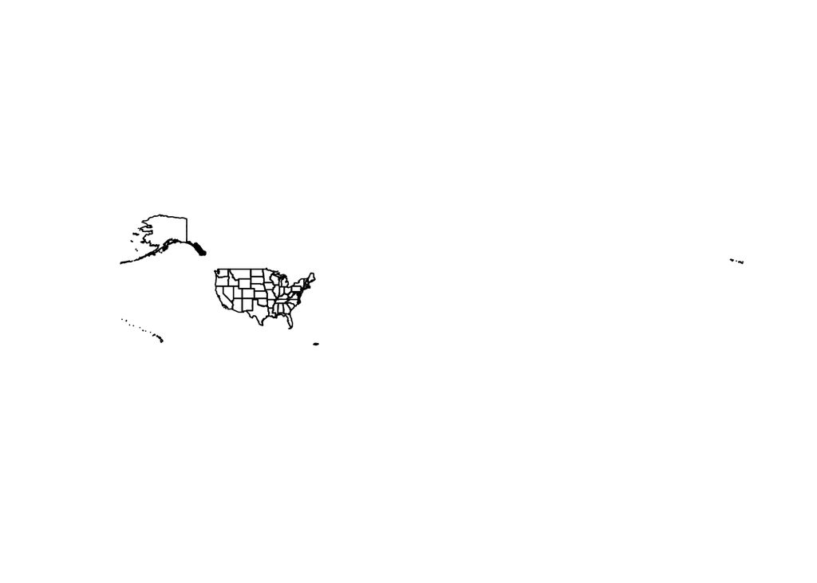

```r
# plot the geometry column data
plot(pop2010geo$geometry)
```

## The Challenge of US maps

The vast geographic extent and non-contiguous nature of the USA makes it difficult to map.

Fortunately, tidycensus includes a `shift_geo` parameter to shift AK & HI to below Texas.

```r
pop2010geo_shifted <- get_decennial(geography = "state",
                                    variables = c(pop10="P001001"),
                                    output="wide",
                                    year = 2010,
                                    geometry=TRUE,
                                    shift_geo=TRUE)
```

```
## Using feature geometry obtained from the albersusa package
```

```
## Using Census Summary File 1
```

```
## Please note: Alaska and Hawaii are being shifted and are not to scale.
```

```
## old-style crs object detected; please recreate object with a recent sf::st_crs()
```

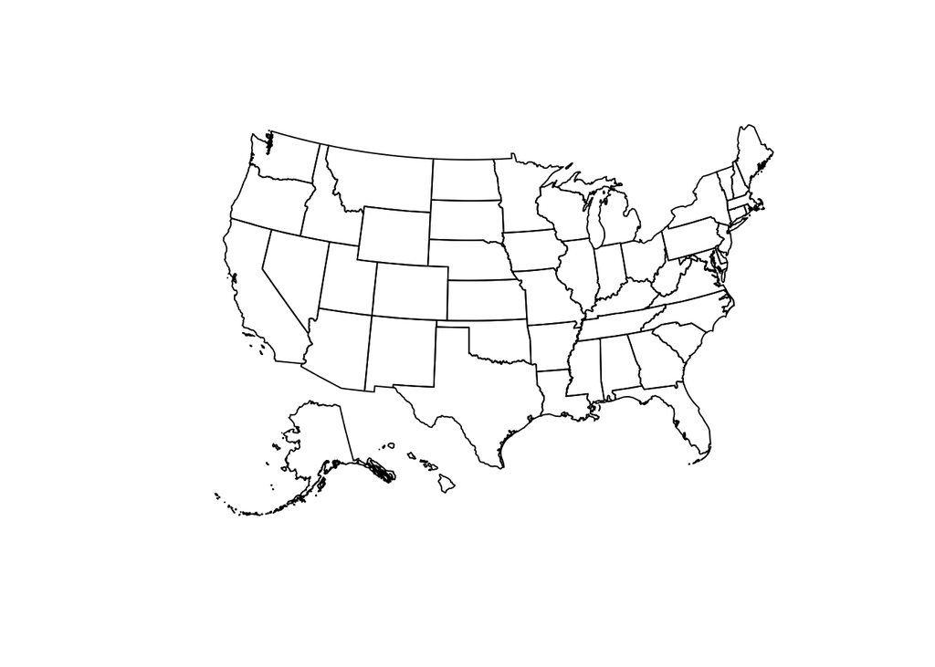

```r
## Shift Happens!
plot(pop2010geo_shifted$geometry)
```

## Save it

You can save any `sf` data object to a shapefile using `st_write`

```r
st_write(pop2010geo_shifted, "data_out/usa_pop2010_shifted.shp")
```

## Check it out

```r
# Check to see if the data was written out to a shapefile
dir("data_out")
```

## Mapping Data Values

You can use the sf `plot` command to make a map that sets the color of the geometry by the data values

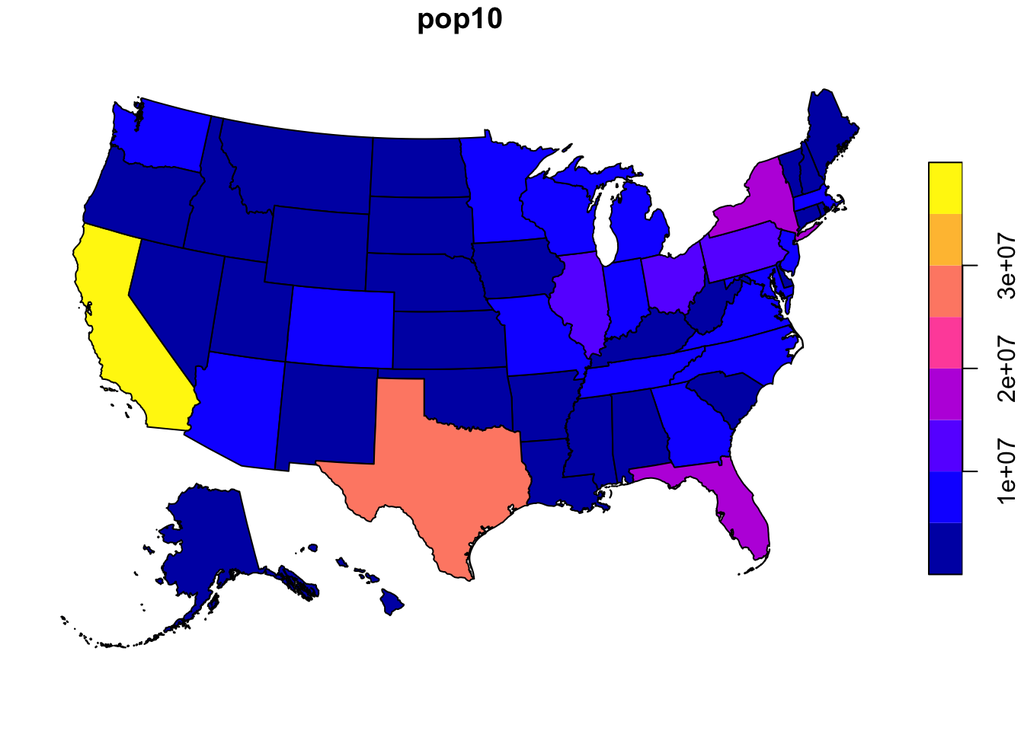

```r
# Name the column with the variable values to make
# a thematic map, also called a choropleth map.
plot(pop2010geo_shifted['pop10'])
```

## `ggplot2` Map

ggplot knows what to do with sf objects!

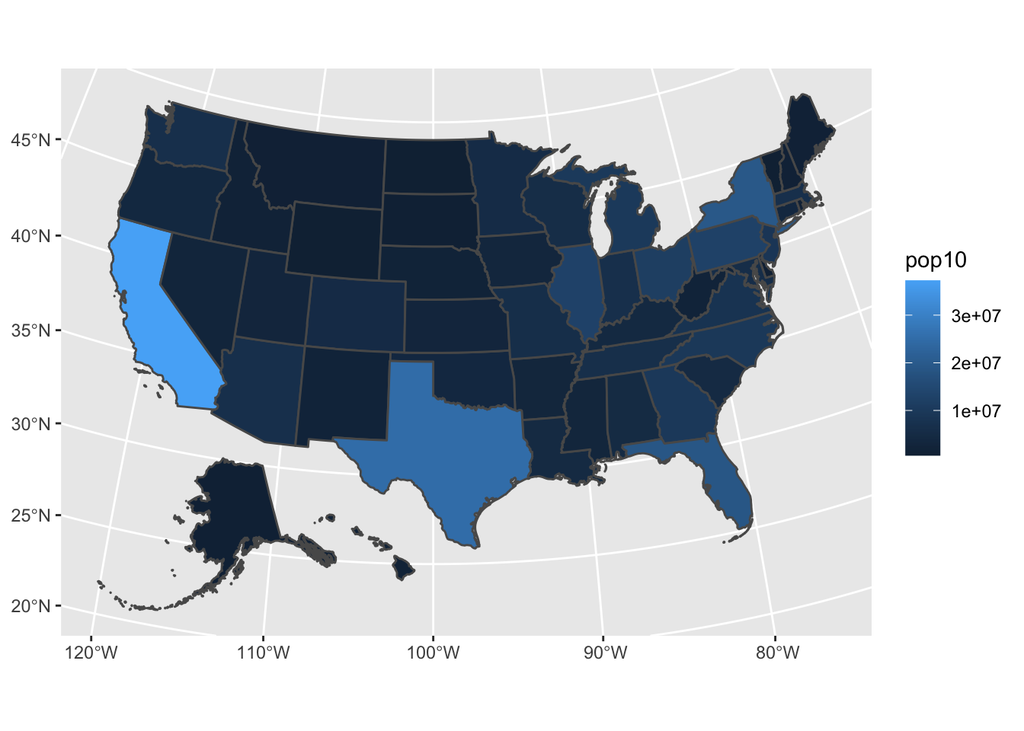

```r
ggplot(pop2010geo_shifted, aes(fill = pop10)) +
  geom_sf()  # tells ggplot that geographic data are being plotted
```

## Let’s make that map prettier

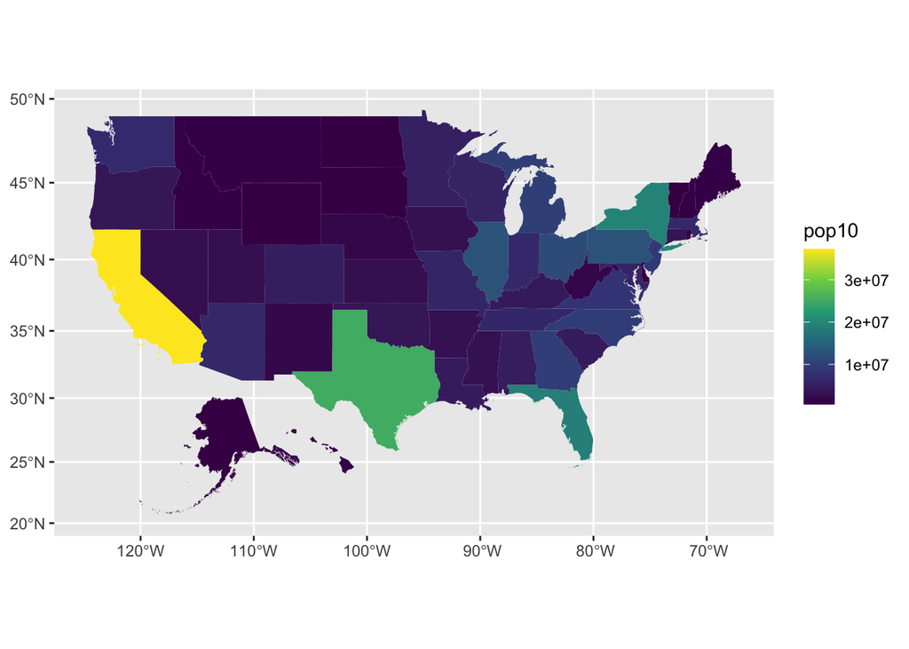

```r
ggplot(pop2010geo_shifted, aes(fill = pop10)) +
  geom_sf(color=NA) + # What does color=NA do
  coord_sf(crs = 3857) + # Dynamically change the CRS
  scale_fill_viridis_c(option = "viridis")  # Change the color palette
```

```r
                                            # Try different options, e.g.
                                            # plasma, magma, inferno, cividis
```

## Challenge

Create a `map` of CA Median Age by county in 2010

```r
# add your code below - solution in Solutions.R
## Fetch data + geometry for CA Median Age by county in 2010

## Map the data with the plot function

## Map the data with ggplot, setting the CRS to 3310 (CA Albers)
## which is the preferred CRS for statewide maps of CA
```

## Fetch Census Data and Geometry for Multiple States or Counties

We can fetch Census data and the **geometry** for more than one state or county with same function call.

- This is so much easier than any alternative approach!
- It can be applied to any available geographic tabulation areas (eg states, counties, tracts, places).

Let’s try it with Census Tracts!

Fetch tract population and geometry data for Bay Area Counties.

```r
bay_counties <- c("Alameda", "Contra Costa", "Marin", "San Francisco",
                  "Sonoma", "Napa","Solano", "San Mateo", "Santa Clara")

bayarea_pop10 <- get_decennial(geography = "tract",
                      variables = "P001001",
                      year = 2010,
                      state='CA',
                      county=bay_counties,
                      geometry=T)
```

```
## Using Census Summary File 1
```

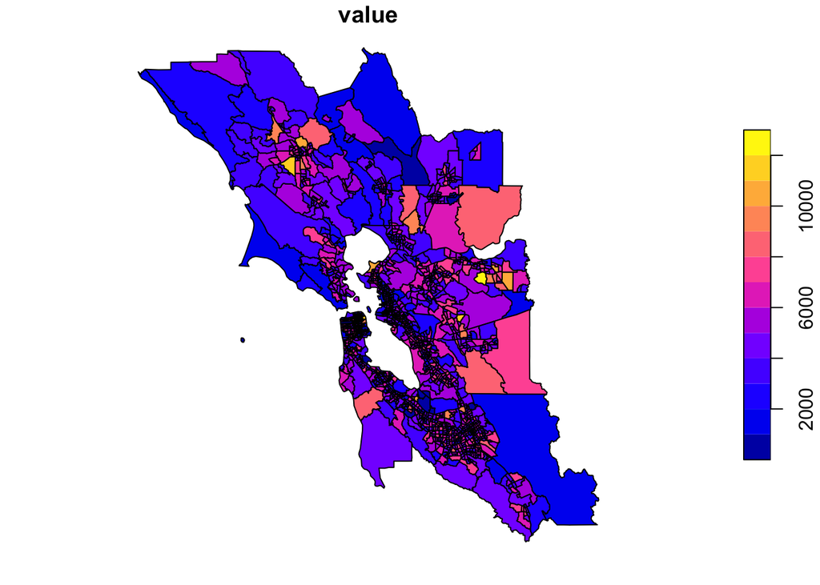

```r
# Quick map
plot(bayarea_pop10['value'])
```